# Case Study: House Prices and Regressions

DS 6371 Project 1

Nicholas Sager

3/31/2023

## Introduction

For an interactive app to visualize this data, please see: [Shiny App](https://nicksager.shinyapps.io/CaseStudy1/)

## Data Description

### Read the Data

```r
train <- read.csv("Data/train.csv")
test <- read.csv("Data/test.csv")

# Merge the data frames and add a column indicating whether they come from the train or test set
train$train <- 1
test$SalePrice <- NA
test$train <- 0
ames <- rbind(train, test)

# Verify data frame
head(ames)
```

```
##   Id MSSubClass MSZoning LotFrontage LotArea Street Alley LotShape LandContour
## 1  1         60       RL          65    8450   Pave  <NA>      Reg         Lvl
## 2  2         20       RL          80    9600   Pave  <NA>      Reg         Lvl
## 3  3         60       RL          68   11250   Pave  <NA>      IR1         Lvl
## 4  4         70       RL          60    9550   Pave  <NA>      IR1         Lvl
## 5  5         60       RL          84   14260   Pave  <NA>      IR1         Lvl
## 6  6         50       RL          85   14115   Pave  <NA>      IR1         Lvl
##   Utilities LotConfig LandSlope Neighborhood Condition1 Condition2 BldgType
## 1    AllPub    Inside       Gtl      CollgCr       Norm       Norm     1Fam
## 2    AllPub       FR2       Gtl      Veenker      Feedr       Norm     1Fam
## 3    AllPub    Inside       Gtl      CollgCr       Norm       Norm     1Fam
## 4    AllPub    Corner       Gtl      Crawfor       Norm       Norm     1Fam
## 5    AllPub       FR2       Gtl      NoRidge       Norm       Norm     1Fam
## 6    AllPub    Inside       Gtl      Mitchel       Norm       Norm     1Fam
##   HouseStyle OverallQual OverallCond YearBuilt YearRemodAdd RoofStyle RoofMatl
```

[output cut: 69 more lines]

```r
str(ames)
```

```
## 'data.frame':    2919 obs. of  82 variables:
##  $ Id           : int  1 2 3 4 5 6 7 8 9 10 ...
##  $ MSSubClass   : int  60 20 60 70 60 50 20 60 50 190 ...
##  $ MSZoning     : chr  "RL" "RL" "RL" "RL" ...
##  $ LotFrontage  : int  65 80 68 60 84 85 75 NA 51 50 ...
##  $ LotArea      : int  8450 9600 11250 9550 14260 14115 10084 10382 6120 7420 ...
##  $ Street       : chr  "Pave" "Pave" "Pave" "Pave" ...
##  $ Alley        : chr  NA NA NA NA ...
##  $ LotShape     : chr  "Reg" "Reg" "IR1" "IR1" ...
##  $ LandContour  : chr  "Lvl" "Lvl" "Lvl" "Lvl" ...
##  $ Utilities    : chr  "AllPub" "AllPub" "AllPub" "AllPub" ...
##  $ LotConfig    : chr  "Inside" "FR2" "Inside" "Corner" ...
##  $ LandSlope    : chr  "Gtl" "Gtl" "Gtl" "Gtl" ...
##  $ Neighborhood : chr  "CollgCr" "Veenker" "CollgCr" "Crawfor" ...
##  $ Condition1   : chr  "Norm" "Feedr" "Norm" "Norm" ...
```

[output cut: 68 more lines]

```r
summary(ames)
```

```
##        Id           MSSubClass       MSZoning          LotFrontage
##  Min.   :   1.0   Min.   : 20.00   Length:2919        Min.   : 21.00
##  1st Qu.: 730.5   1st Qu.: 20.00   Class :character   1st Qu.: 59.00
##  Median :1460.0   Median : 50.00   Mode  :character   Median : 68.00
##  Mean   :1460.0   Mean   : 57.14                      Mean   : 69.31
##  3rd Qu.:2189.5   3rd Qu.: 70.00                      3rd Qu.: 80.00
##  Max.   :2919.0   Max.   :190.00                      Max.   :313.00
##                                                       NA's   :486
##     LotArea          Street             Alley             LotShape
##  Min.   :  1300   Length:2919        Length:2919        Length:2919
##  1st Qu.:  7478   Class :character   Class :character   Class :character
##  Median :  9453   Mode  :character   Mode  :character   Mode  :character
##  Mean   : 10168
##  3rd Qu.: 11570
##  Max.   :215245
##
##  LandContour         Utilities          LotConfig          LandSlope
##  Length:2919        Length:2919        Length:2919        Length:2919
##  Class :character   Class :character   Class :character   Class :character
##  Mode  :character   Mode  :character   Mode  :character   Mode  :character
##
##
##
##
##  Neighborhood        Condition1         Condition2          BldgType
##  Length:2919        Length:2919        Length:2919        Length:2919
##  Class :character   Class :character   Class :character   Class :character
##  Mode  :character   Mode  :character   Mode  :character   Mode  :character
##
##
##
##
##   HouseStyle         OverallQual      OverallCond      YearBuilt
##  Length:2919        Min.   : 1.000   Min.   :1.000   Min.   :1872
##  Class :character   1st Qu.: 5.000   1st Qu.:5.000   1st Qu.:1954
##  Mode  :character   Median : 6.000   Median :5.000   Median :1973
##                     Mean   : 6.089   Mean   :5.565   Mean   :1971
##                     3rd Qu.: 7.000   3rd Qu.:6.000   3rd Qu.:2001
##                     Max.   :10.000   Max.   :9.000   Max.   :2010
##
```

[output cut: 113 more lines]

```
##  Min.   : 1.000   Min.   :2006   Length:2919        Length:2919
##  1st Qu.: 4.000   1st Qu.:2007   Class :character   Class :character
##  Median : 6.000   Median :2008   Mode  :character   Mode  :character
##  Mean   : 6.213   Mean   :2008
##  3rd Qu.: 8.000   3rd Qu.:2009
##  Max.   :12.000   Max.   :2010
##
##    SalePrice          train
##  Min.   : 34900   Min.   :0.0000
##  1st Qu.:129975   1st Qu.:0.0000
##  Median :163000   Median :1.0000
##  Mean   :180921   Mean   :0.5002
##  3rd Qu.:214000   3rd Qu.:1.0000
##  Max.   :755000   Max.   :1.0000
##  NA's   :1459
```

For data cleaning purposes, we will merge test and train into one dataset, keeping in mind that the 1459 NA’s in the SalePrice column are from the test set. We will also add a column to indicate whether the row is from the train or test set.

### Data Exploration

Next, we will start exploring the data for insights into the Ames housing market as well as what variables we need to change, clean, or create.

First, we will visualize where the NA values are and whether it will affect the first to parameters we are concerned about: Sale Price and Gross Living Area.

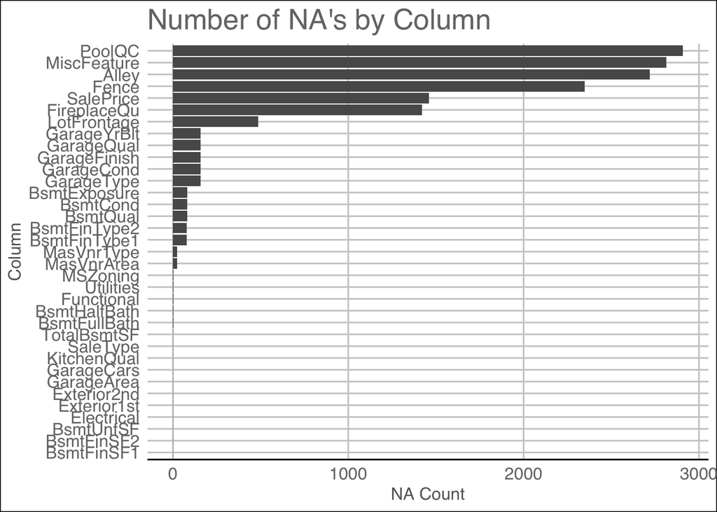

```r
# Summarize NA's by  column
ames %>%
  summarise_all(funs(sum(is.na(.)))) %>%
  gather(key = "Column", value = "NA_Count", -1) %>%
  filter(NA_Count > 0) %>%
  ggplot(aes(x = reorder(Column, NA_Count), y = NA_Count)) +
  geom_col() +
  coord_flip() +
  theme_gdocs() +
  labs(title = "Number of NA's by Column", x = "Column", y = "NA Count")
```

```r
# Create a table of the missing NAs by column
ames %>%
  summarise_all(funs(sum(is.na(.)))) %>%
  gather(key = "Column", value = "NA_Count", -1) %>%
  filter(NA_Count > 0) %>%
  arrange(desc(NA_Count)) %>%
  kable()
```

| Id | Column | NA_Count |
| --- | --- | --- |
| 0 | PoolQC | 2909 |
| 0 | MiscFeature | 2814 |
| 0 | Alley | 2721 |
| 0 | Fence | 2348 |
| 0 | SalePrice | 1459 |
| 0 | FireplaceQu | 1420 |
| 0 | LotFrontage | 486 |
| 0 | GarageYrBlt | 159 |
| 0 | GarageFinish | 159 |
| 0 | GarageQual | 159 |
| 0 | GarageCond | 159 |
| 0 | GarageType | 157 |
| 0 | BsmtCond | 82 |
| 0 | BsmtExposure | 82 |
| 0 | BsmtQual | 81 |
| 0 | BsmtFinType2 | 80 |
| 0 | BsmtFinType1 | 79 |
| 0 | MasVnrType | 24 |
| 0 | MasVnrArea | 23 |
| 0 | MSZoning | 4 |
| 0 | Utilities | 2 |
| 0 | BsmtFullBath | 2 |
| 0 | BsmtHalfBath | 2 |
| 0 | Functional | 2 |
| 0 | Exterior1st | 1 |
| 0 | Exterior2nd | 1 |
| 0 | BsmtFinSF1 | 1 |
| 0 | BsmtFinSF2 | 1 |
| 0 | BsmtUnfSF | 1 |
| 0 | TotalBsmtSF | 1 |
| 0 | Electrical | 1 |
| 0 | KitchenQual | 1 |
| 0 | GarageCars | 1 |
| 0 | GarageArea | 1 |
| 0 | SaleType | 1 |

There are not too many NA’s in the data set, and they appear mostly to do with lack of a certain feature. For example, if a house does not have a pool, then the PoolQC column will be NA. We will need to decide how to handle these NA’s, but for now we will leave them as is and continue with the analysis of Sale Price and Gross Living Area.

## Analysis 1: Sale Price and Gross Living Area

### Build and fit the model

#### Entire Dataset

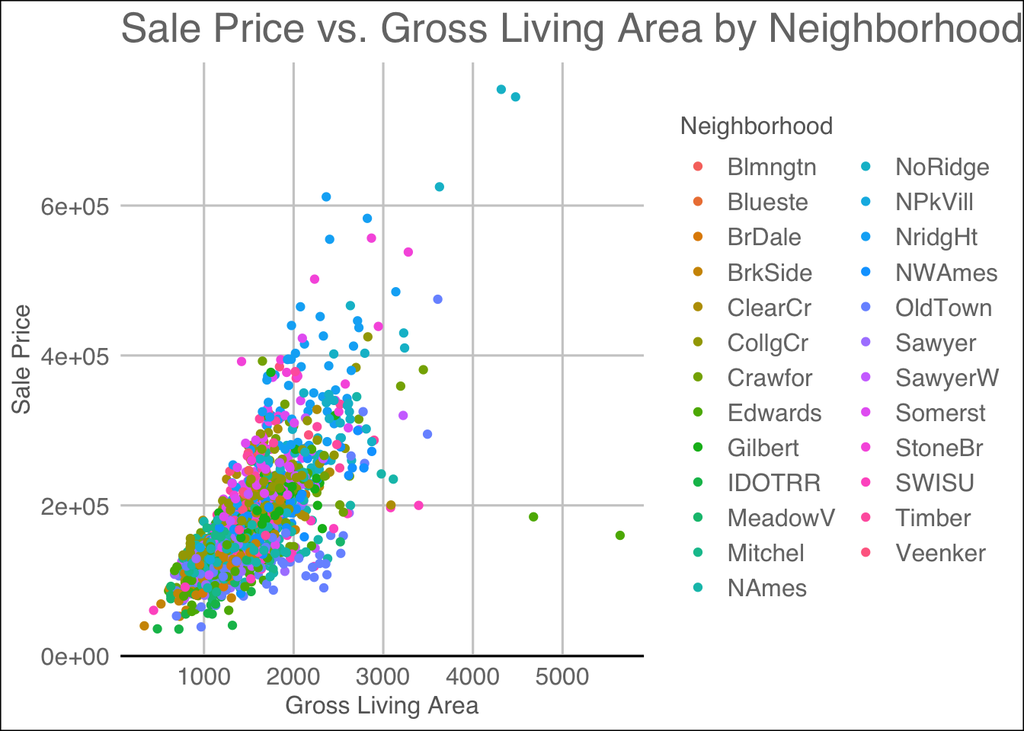

```r
# Plot Sale Price vs. Gross Living Area colored by neighborhood, omitting rows where SalePrice is NA
ames %>%
  filter(!is.na(SalePrice)) %>%
  ggplot(aes(x = GrLivArea, y = SalePrice, color = Neighborhood)) +
  geom_point() +
  theme_gdocs() +
  labs(title = "Sale Price vs. Gross Living Area by Neighborhood", x = "Gross Living Area", y = "Sale Price")
```

There is clearly a relationship between Sale Price and Gross Living Area, and the neighborhoods appear to have a similar relationship. We will now look at log transformations of the data to see if there is more linear relationship.

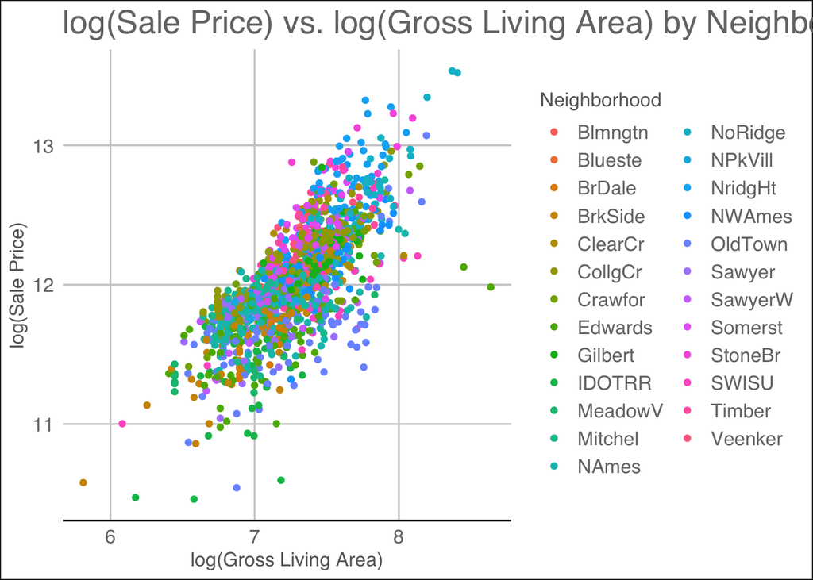

```r
# Plot log(Sale Price) vs. log(Gross Living Area) colored by neighborhood, omitting rows where SalePrice is NA
ames %>%
  filter(!is.na(SalePrice)) %>%
  ggplot(aes(x = log(GrLivArea), y = log(SalePrice), color = Neighborhood)) +
  geom_point() +
  theme_gdocs() +
  labs(
    title = "log(Sale Price) vs. log(Gross Living Area) by Neighborhood",
    x = "log(Gross Living Area)",
    y = "log(Sale Price)"
  )
```

This relationship appears to be more linear. We will create columns for the log of Sale Price and Gross Living Area and use these in our analysis.

```r
# Create columns for log(SalePrice) and log(GrLivArea)
ames$logSalePrice <- log(ames$SalePrice)
ames$logGrLivArea <- log(ames$GrLivArea)

PRESS <- function(linear.model) {
  #' calculate the predictive residuals
  pr <- residuals(linear.model) / (1 - lm.influence(linear.model)$hat)
  #' calculate the PRESS
  PRESS <- sum(pr^2)

  return(PRESS)
}
# Function for calculating PRESS
# Tom Hopper
# https://gist.github.com/tomhopper/8c204d978c4a0cbcb8c0
```

^Just some code for CV PRESS and log transformations. Jae: What do you think about using AIC rather than PRESS? The models are optimised using AIC.

#### Century 21 Area

Next, we will visualize the relationship between log Sale Price and log Gross Living Area for the neighborhoods that Century21 operates in: NAmes, Edwards and BrkSide.

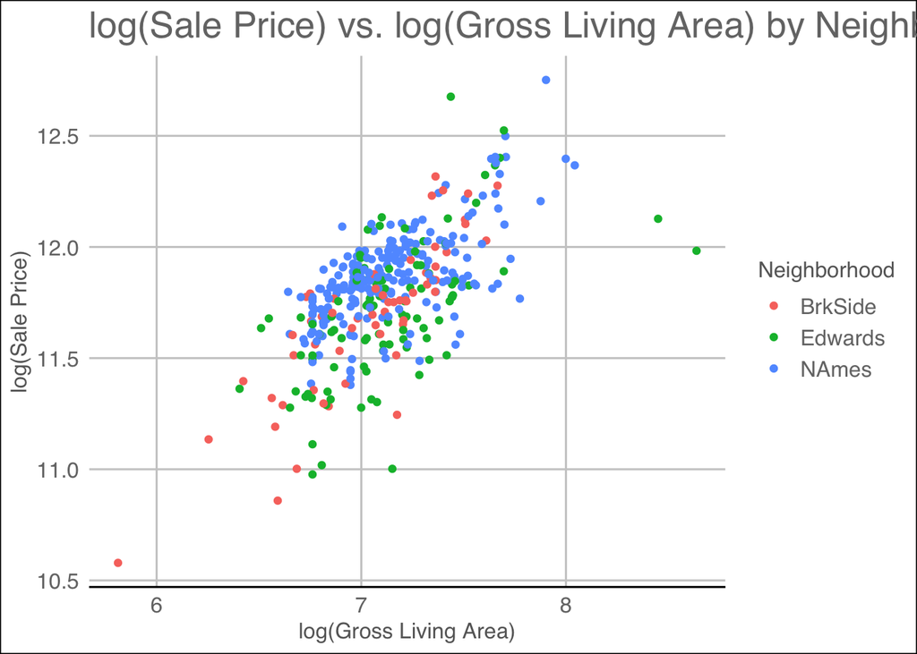

```r
# Plot log(Sale Price) vs. log(Gross Living Area) colored by neighborhood, omitting rows where SalePrice is NA for only the neighborhoods of interest
century21 <-
  ames %>%
  filter(!is.na(SalePrice)) %>%
  filter(Neighborhood %in% c("NAmes", "Edwards", "BrkSide"))
century21 %>%
  ggplot(aes(x = logGrLivArea, y = logSalePrice, color = Neighborhood)) +
  geom_point() +
  theme_gdocs() +
  labs(
    title = "log(Sale Price) vs. log(Gross Living Area) by Neighborhood",
    x = "log(Gross Living Area)",
    y = "log(Sale Price)"
  )
```

The relationship appears to be linear, so we will fit a linear model using this data and asses whether it describes the Sale Prices accurately.

```r
# Fit a linear model to the data
fit1x <- lm(logSalePrice ~ logGrLivArea + Neighborhood, data = century21)
summary(fit1x)
```

```
##
## Call:
## lm(formula = logSalePrice ~ logGrLivArea + Neighborhood, data = century21)
##
## Residuals:
##      Min       1Q   Median       3Q      Max
## -0.72154 -0.10592  0.02469  0.11565  0.79364
##
## Coefficients:
##                     Estimate Std. Error t value Pr(>|t|)
## (Intercept)          7.76936    0.22919  33.900  < 2e-16 ***
## logGrLivArea         0.55579    0.03237  17.171  < 2e-16 ***
## NeighborhoodEdwards -0.02044    0.03252  -0.629     0.53
## NeighborhoodNAmes    0.13279    0.02906   4.569 6.63e-06 ***
## ---
## Signif. codes:  0 '***' 0.001 '**' 0.01 '*' 0.05 '.' 0.1 ' ' 1
##
## Residual standard error: 0.1961 on 379 degrees of freedom
## Multiple R-squared:  0.4897, Adjusted R-squared:  0.4857
## F-statistic: 121.2 on 3 and 379 DF,  p-value: < 2.2e-16
```

```r
PRESS(fit1x)
```

```
## [1] 15.00131
```

```r
# Fit a linear model to the data with interaction variables
fit1 <- lm(logSalePrice ~ logGrLivArea * Neighborhood, data = century21)
summary(fit1)
```

```
##
## Call:
## lm(formula = logSalePrice ~ logGrLivArea * Neighborhood, data = century21)
##
## Residuals:
##      Min       1Q   Median       3Q      Max
## -0.72080 -0.10353  0.02184  0.10586  0.80470
##
## Coefficients:
##                                  Estimate Std. Error t value Pr(>|t|)
## (Intercept)                       5.91292    0.50459  11.718  < 2e-16 ***
## logGrLivArea                      0.81965    0.07163  11.443  < 2e-16 ***
## NeighborhoodEdwards               2.09359    0.64589   3.241   0.0013 **
## NeighborhoodNAmes                 2.57981    0.59988   4.301 2.17e-05 ***
## logGrLivArea:NeighborhoodEdwards -0.29998    0.09122  -3.289   0.0011 **
## logGrLivArea:NeighborhoodNAmes   -0.34662    0.08482  -4.087 5.35e-05 ***
## ---
## Signif. codes:  0 '***' 0.001 '**' 0.01 '*' 0.05 '.' 0.1 ' ' 1
##
## Residual standard error: 0.1923 on 377 degrees of freedom
## Multiple R-squared:  0.5121, Adjusted R-squared:  0.5056
## F-statistic: 79.14 on 5 and 377 DF,  p-value: < 2.2e-16
```

```r
PRESS(fit1)
```

```
## [1] 14.60908
```

```r
confint(fit1) %>% kable()
```

|  | 2.5 % | 97.5 % |
| --- | --- | --- |
| (Intercept) | 4.9207572 | 6.9050843 |
| logGrLivArea | 0.6788064 | 0.9604897 |
| NeighborhoodEdwards | 0.8235795 | 3.3635933 |
| NeighborhoodNAmes | 1.4002744 | 3.7593394 |
| logGrLivArea:NeighborhoodEdwards | -0.4793353 | -0.1206263 |
| logGrLivArea:NeighborhoodNAmes | -0.5134042 | -0.1798447 |

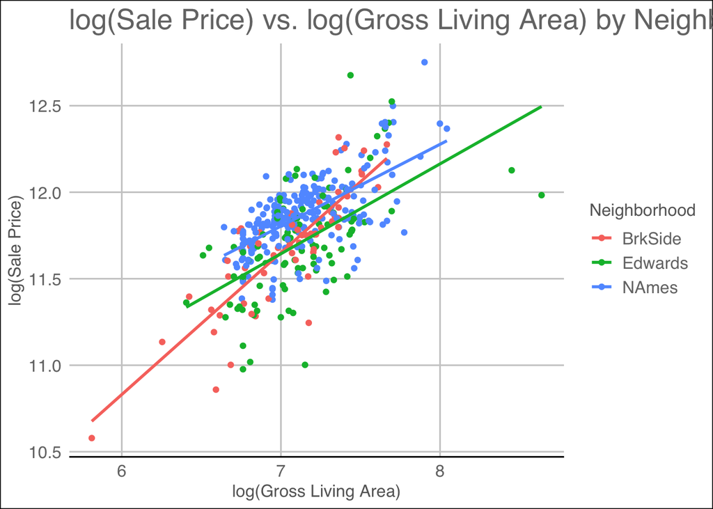

```r
# Plot the data with the linear model superposed
century21 %>%
  ggplot(aes(x = logGrLivArea, y = logSalePrice, color = Neighborhood)) +
  geom_point() +
  theme_gdocs() +
  labs(
    title = "log(Sale Price) vs. log(Gross Living Area) by Neighborhood",
    x = "log(Gross Living Area)",
    y = "log(Sale Price)"
  ) +
  geom_smooth(
    method = "lm", formula = y ~ x, se = FALSE, linewidth = 1,
    data = data.frame(
      logGrLivArea = century21$logGrLivArea,
      Neighborhood = century21$Neighborhood,
      logSalePrice = predict(fit1)
    )
  )
```

```r
# # Print parameter estimate table nicely. Not working, needs debugging
# fit1 %>%
#   summary() %>%
#   {cbind(as.data.frame(coef(.)), .[["coefficients"]][, 2:4])} %>%
#   setNames(c("Estimate", "Std. Error", "t-value", "Pr(>|t|)")) %>%
#   rownames_to_column(var = "Term") %>%
#   mutate(Term = ifelse(Term == "(Intercept)", "Intercept", Term)) %>%
#   add_row(Term = "Adjusted R-squared", Estimate = round(.$adj.r.squared, 3), Std..Error = NA, `t-value` = NA, `Pr(>|t|)` = NA) %>%
#   kable(digits = 3, align = "c") %>%
#   kable_styling(full_width = FALSE)
```

We fit models with and without interaction terms. The interaction terms are statistically significant (include p values) and the model with interaction terms has a lower PRESS. This means that the relationship between log sale price and log gross living area is different for each neighborhood.

It might be good to test whether Edwards and NAmes are are statistically different. We could do that by re-referencing or doing the BYOA method.

### Check the Assumptions

#### Residual Plots

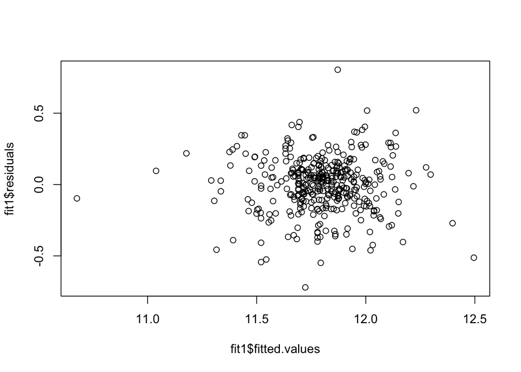

```r
# Plot the studentized residuals using base R
plot(fit1$fitted.values, fit1$residuals, type = "p")
```

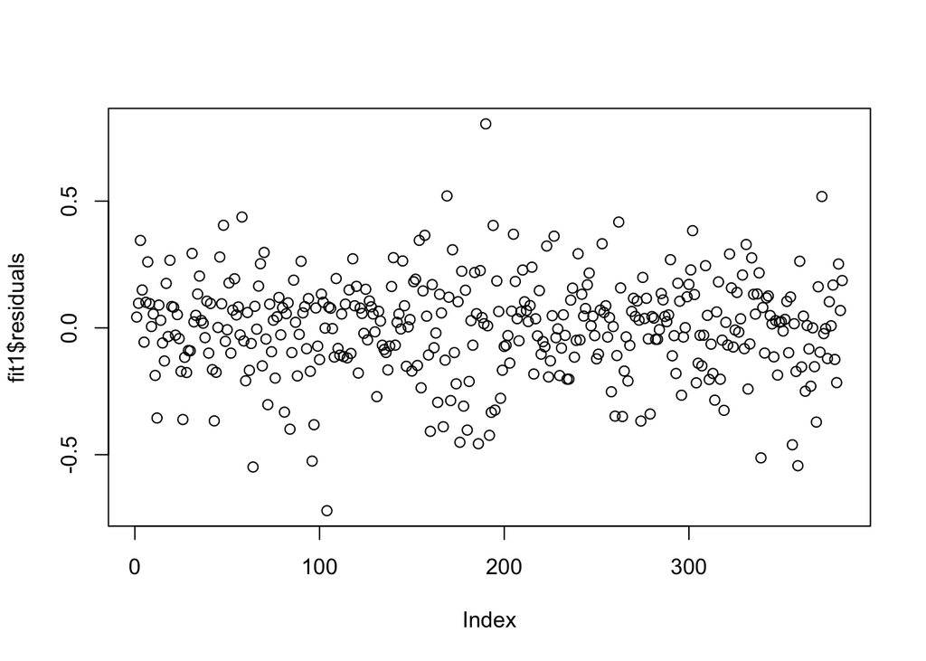

```r
plot(fit1$residuals)
```

[figure not shown]

```r
# Decide which of these we like better ggplot or R

# Calculate studentized residuals
stud_res <- rstudent(fit1)
# Create a data frame with the studentized residuals
df <- data.frame(stud_res, logGrLivArea = model.frame(fit1)$logGrLivArea)

# Create a scatterplot of the studentized residuals
ggplot(df, aes(x = logGrLivArea, y = stud_res)) +
  geom_point() +
  labs(title = "Scatterplot of Studentized Residuals",
  x = "Studentized Residuals",
  y = "Frequency") +
  theme_minimal()
```

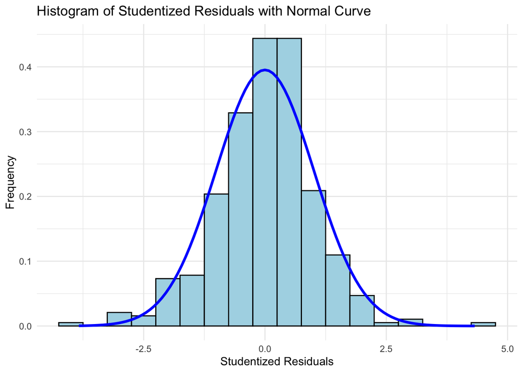

```r
# Create histogram with normal curve
ggplot(df, aes(x = stud_res)) +
  geom_histogram(aes(y = ..density..), binwidth = 0.5, fill = "lightblue", color = "black") +
  stat_function(fun = dnorm, args = list(mean = mean(df$stud_res), sd = sd(df$stud_res)), color = "blue", size = 1.2) +
  labs(title = "Histogram of Studentized Residuals with Normal Curve",
  x = "Studentized Residuals",
  y = "Frequency") +
  theme_minimal()
```

The plots show the same thing, please include whichever style you think looks better. There is no evidence of non-linearity, heteroscedasticity, or non-normality.

#### Influential Points

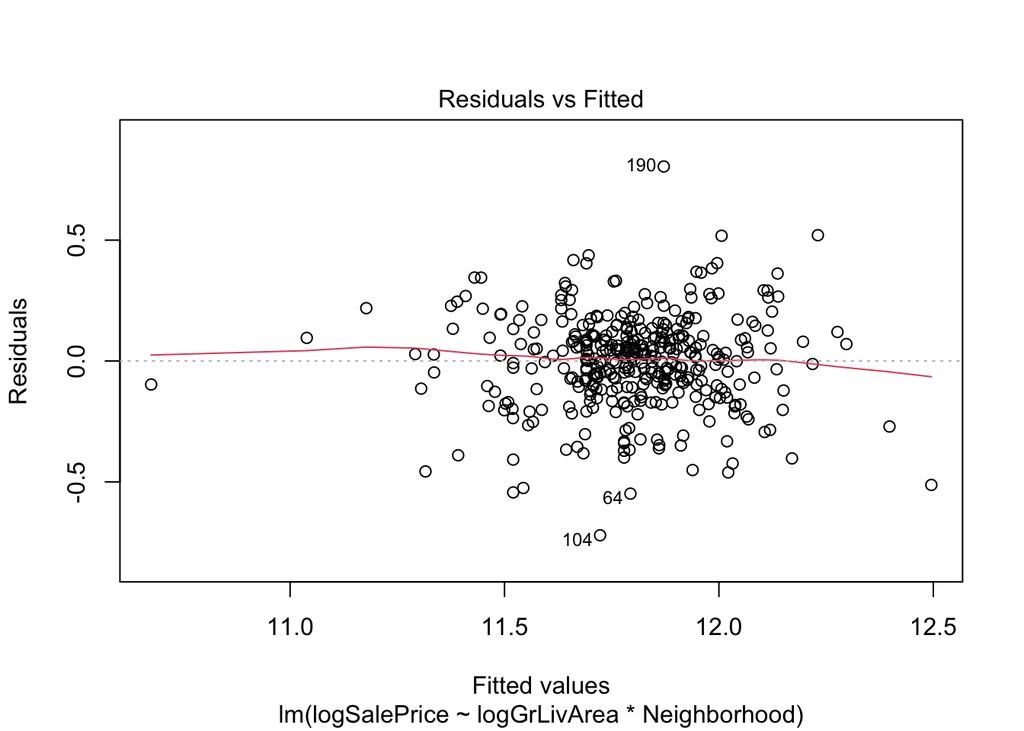

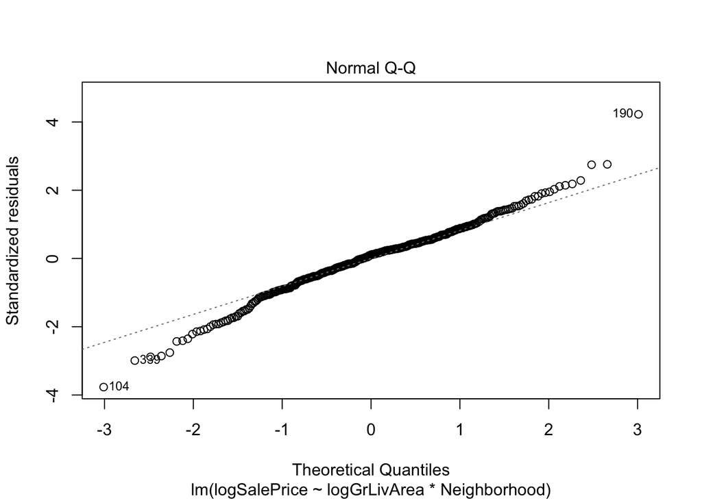

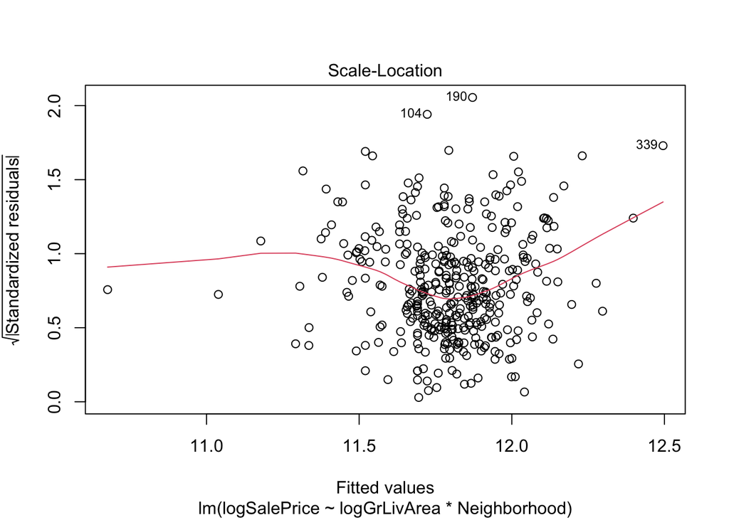

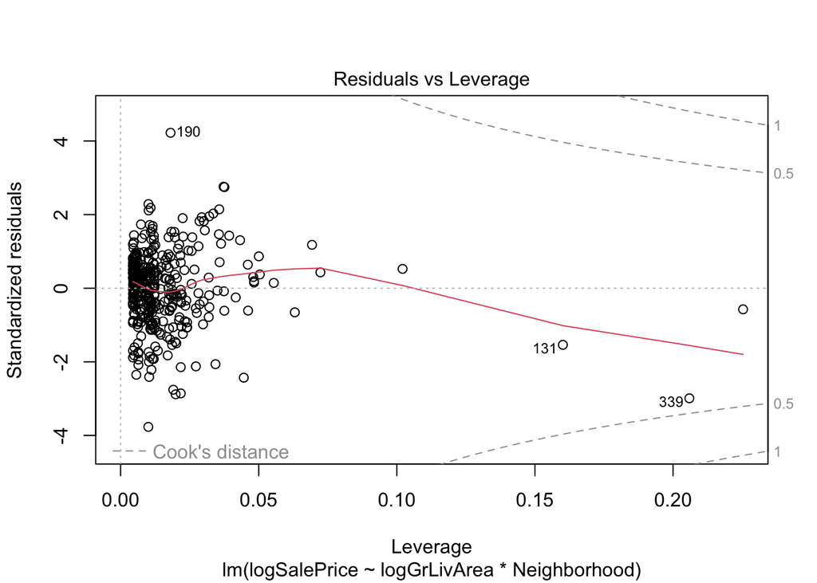

```r
# Plot the residuals vs. the fitted values
fit1 %>%
  plot()
```

There are no influential points that need to be investigated. The results are consistent with the assumptions of the linear model.

## Analysis 2: Sale Price

### Data Cleaning

In order to use a linear regression model, we need to convert all of the categorical variables into dummy variables. We will also remove or impute the NA’s in the data set. Please see the appendix for details on this process.

```r
# Data Cleaning

# If pool-related variables are NA, assume there is no pool and assign to 0
ames <- ames %>%
  mutate(
    PoolQC = ifelse(is.na(PoolQC), "None", PoolQC),
    PoolArea = ifelse(is.na(PoolArea), 0, PoolArea),
  )
# If garage-related variables are NA, assume there is no garage and assign to 0
ames <- ames %>%
  mutate(
    GarageType = ifelse(is.na(GarageType), "None", GarageType),
    #GarageYrBlt = ifelse(is.na(GarageYrBlt), 0, GarageYrBlt), #These will be changed to the mean because of large year values
    GarageFinish = ifelse(is.na(GarageFinish), "None", GarageFinish),
    GarageCars = ifelse(is.na(GarageCars), 0, GarageCars),
    GarageArea = ifelse(is.na(GarageArea), 0, GarageArea),
    GarageQual = ifelse(is.na(GarageQual), "None", GarageQual),
    GarageCond = ifelse(is.na(GarageCond), "None", GarageCond)
  )
# If Bsmt-related variables are NA, assume there is no Bsmt and assign to 0
ames <- ames %>%
  mutate(
    BsmtQual = ifelse(is.na(BsmtQual), "None", BsmtQual),
    BsmtCond = ifelse(is.na(BsmtCond), "None", BsmtCond),
    BsmtExposure = ifelse(is.na(BsmtExposure), "None", BsmtExposure),
    BsmtFinType1 = ifelse(is.na(BsmtFinType1), "None", BsmtFinType1),
    BsmtFinSF1 = ifelse(is.na(BsmtFinSF1), 0, BsmtFinSF1),
    BsmtFinType2 = ifelse(is.na(BsmtFinType2), "None", BsmtFinType2),
    BsmtFinSF2 = ifelse(is.na(BsmtFinSF2), 0, BsmtFinSF2),
    BsmtUnfSF = ifelse(is.na(BsmtUnfSF), 0, BsmtUnfSF),
    TotalBsmtSF = ifelse(is.na(TotalBsmtSF), 0, TotalBsmtSF)
  )
# If Fence-related variables are NA, assume there is no Fence and assign to 0
ames <- ames %>%
  mutate(
    Fence = ifelse(is.na(Fence), "None", Fence),
  )
# If Misc-related variables are NA, assume there is no Misc features and assign to 0
ames <- ames %>%
  mutate(
    MiscFeature = ifelse(is.na(MiscFeature), "None", MiscFeature),
  )
# If Fireplace-related variables are NA, assume there is no Fireplace and assign to 0
ames <- ames %>%
  mutate(
    FireplaceQu = ifelse(is.na(FireplaceQu), "None", FireplaceQu),
  )
# If Alley-related variables are NA, assume there is no Alley and assign to 0
ames <- ames %>%
  mutate(
    Alley = ifelse(is.na(Alley), "None", Alley),
  )

# Summarize the amount of remaining NA's by column to check what's left
colSums(is.na(ames))
```

```
##            Id    MSSubClass      MSZoning   LotFrontage       LotArea
##             0             0             4           486             0
##        Street         Alley      LotShape   LandContour     Utilities
##             0             0             0             0             2
##     LotConfig     LandSlope  Neighborhood    Condition1    Condition2
##             0             0             0             0             0
##      BldgType    HouseStyle   OverallQual   OverallCond     YearBuilt
##             0             0             0             0             0
##  YearRemodAdd     RoofStyle      RoofMatl   Exterior1st   Exterior2nd
##             0             0             0             1             1
##    MasVnrType    MasVnrArea     ExterQual     ExterCond    Foundation
##            24            23             0             0             0
##      BsmtQual      BsmtCond  BsmtExposure  BsmtFinType1    BsmtFinSF1
##             0             0             0             0             0
##  BsmtFinType2    BsmtFinSF2     BsmtUnfSF   TotalBsmtSF       Heating
##             0             0             0             0             0
##     HeatingQC    CentralAir    Electrical     X1stFlrSF     X2ndFlrSF
##             0             0             1             0             0
##  LowQualFinSF     GrLivArea  BsmtFullBath  BsmtHalfBath      FullBath
##             0             0             2             2             0
##      HalfBath  BedroomAbvGr  KitchenAbvGr   KitchenQual  TotRmsAbvGrd
##             0             0             0             1             0
##    Functional    Fireplaces   FireplaceQu    GarageType   GarageYrBlt
##             2             0             0             0           159
##  GarageFinish    GarageCars    GarageArea    GarageQual    GarageCond
##             0             0             0             0             0
##    PavedDrive    WoodDeckSF   OpenPorchSF EnclosedPorch    X3SsnPorch
##             0             0             0             0             0
##   ScreenPorch      PoolArea        PoolQC         Fence   MiscFeature
##             0             0             0             0             0
##       MiscVal        MoSold        YrSold      SaleType SaleCondition
##             0             0             0             1             0
##     SalePrice         train  logSalePrice  logGrLivArea
##          1459             0          1459             0
```

```r
# Use the dummyVars() function to convert categorical variables into dummy variables
# Then use janitor::clean_names() to clean up the column names
dummy_model <- dummyVars(~ ., data = ames)
ames_dummy <- as.data.frame(predict(dummy_model, newdata = ames))
ames_dummy <- clean_names(ames_dummy)

# Fill in all remaining na values with the mean of the column
ames_dummy <- ames_dummy %>%
  mutate(across(
    c(-sale_price, -log_sale_price),
    ~ ifelse(is.na(.), mean(., na.rm = TRUE), .)
  ))
# Summarize the amount of remaining NA's by column
colSums(is.na(ames_dummy))
```

```
##                      id            ms_sub_class         ms_zoning_c_all
##                       0                       0                       0
##            ms_zoning_fv            ms_zoning_rh            ms_zoning_rl
##                       0                       0                       0
##            ms_zoning_rm            lot_frontage                lot_area
##                       0                       0                       0
##             street_grvl             street_pave              alley_grvl
##                       0                       0                       0
##              alley_none              alley_pave           lot_shape_ir1
##                       0                       0                       0
##           lot_shape_ir2           lot_shape_ir3           lot_shape_reg
##                       0                       0                       0
##        land_contour_bnk        land_contour_hls        land_contour_low
##                       0                       0                       0
##        land_contour_lvl       utilities_all_pub      utilities_no_se_wa
##                       0                       0                       0
##       lot_config_corner    lot_config_cul_d_sac          lot_config_fr2
##                       0                       0                       0
##          lot_config_fr3       lot_config_inside          land_slope_gtl
##                       0                       0                       0
##          land_slope_mod          land_slope_sev    neighborhood_blmngtn
##                       0                       0                       0
##    neighborhood_blueste    neighborhood_br_dale   neighborhood_brk_side
##                       0                       0                       0
##   neighborhood_clear_cr   neighborhood_collg_cr    neighborhood_crawfor
##                       0                       0                       0
##    neighborhood_edwards    neighborhood_gilbert     neighborhood_idotrr
##                       0                       0                       0
##   neighborhood_meadow_v    neighborhood_mitchel     neighborhood_n_ames
##                       0                       0                       0
##   neighborhood_no_ridge  neighborhood_n_pk_vill   neighborhood_nridg_ht
##                       0                       0                       0
##    neighborhood_nw_ames   neighborhood_old_town     neighborhood_sawyer
##                       0                       0                       0
##   neighborhood_sawyer_w    neighborhood_somerst   neighborhood_stone_br
##                       0                       0                       0
##      neighborhood_swisu     neighborhood_timber    neighborhood_veenker
##                       0                       0                       0
##        condition1artery         condition1feedr          condition1norm
##                       0                       0                       0
```

[output cut: 151 more lines]

```
##                       0                       0                       0
##           sale_type_cod           sale_type_con        sale_type_con_ld
##                       0                       0                       0
##        sale_type_con_li        sale_type_con_lw           sale_type_cwd
##                       0                       0                       0
##           sale_type_new           sale_type_oth            sale_type_wd
##                       0                       0                       0
##  sale_condition_abnorml sale_condition_adj_land   sale_condition_alloca
##                       0                       0                       0
##   sale_condition_family   sale_condition_normal  sale_condition_partial
##                       0                       0                       0
##              sale_price                   train          log_sale_price
##                    1459                       0                    1459
##         log_gr_liv_area
##                       0
```

```r
# Split the data into training and testing sets
train <- ames_dummy[ames_dummy$train == 1, ]
test <- ames_dummy[ames_dummy$train == 0, ]
```

We can write as much or as little about this as we’d like. Basically, we tried to interpret what the NA’s actually were saying and then make a more informed guess as to what the were rather than going with the mean. In most cases, this created a new category of “none”. Remaining values were imputed to the mean, and the data was split into training and testing sets.

### Model Selection

#### Forward Selection

```r
# Forward Selection

# # Testing olsrr method.
# library(olsrr)
# fit2x <- lm(log_sale_price ~ . - sale_price, data = train)
# fit2y <- ols_step_forward_p(fit2x, penter = 0.15)$model
# summary(fit2y)
# defaultSummary(data.frame(pred = predict(fit2y), obs = train$log_sale_price))
# PRESS(fit2y)

# Check if the model object exists, train if it doesn't
if (file.exists("Models/lm_forwards.rds")) {
  # Load the model object from disk
  fit2 <- readRDS("Models/lm_forwards.rds")
} else {
  # Perform stepwise selection

  # Set up a parallel backend with the number of cores you want to use
  cores <- 8 # Change this to the number of cores you want to use
  cl <- makePSOCKcluster(cores)
  registerDoParallel(cl)

  set.seed(137)
  ctrl <- trainControl(
    method = "boot",
    number = 5,
    allowParallel = TRUE
  )
  fit2 <- train(log_sale_price ~ . - sale_price,
    data = train,
    method = "glmStepAIC",
    trControl = ctrl,
    direction = "forward",
    penter = 0.05 # Not Working.
  )

  # Stop the parallel backend
  stopCluster(cl)

  # Save the model object to disk
  saveRDS(fit2, "Models/lm_forwards.rds")
}

summary(fit2$finalModel)
```

```
##
## Call:
## NULL
##
## Deviance Residuals:
##      Min        1Q    Median        3Q       Max
## -0.71103  -0.04529   0.00088   0.05269   0.60423
##
## Coefficients:
##                          Estimate Std. Error t value Pr(>|t|)
## (Intercept)             2.575e+00  5.641e-01   4.565 5.45e-06 ***
## overall_qual            3.809e-02  3.940e-03   9.668  < 2e-16 ***
## log_gr_liv_area         3.724e-01  4.096e-02   9.091  < 2e-16 ***
## year_built              2.109e-03  2.175e-04   9.699  < 2e-16 ***
## overall_cond            4.115e-02  3.341e-03  12.317  < 2e-16 ***
## total_bsmt_sf           1.388e-04  1.218e-05  11.389  < 2e-16 ***
## roof_matl_cly_tile     -2.536e+00  1.522e-01 -16.671  < 2e-16 ***
## bsmt_unf_sf            -5.867e-05  1.210e-05  -4.848 1.39e-06 ***
## garage_cars             2.679e-02  8.629e-03   3.104 0.001946 **
## bldg_type1fam           2.699e-02  1.062e-02   2.541 0.011163 *
## condition2pos_n        -7.879e-01  7.940e-02  -9.923  < 2e-16 ***
## neighborhood_crawfor    1.269e-01  1.617e-02   7.851 8.32e-15 ***
## kitchen_qual_ex         7.455e-02  1.341e-02   5.561 3.22e-08 ***
## ms_zoning_c_all        -4.215e-01  3.485e-02 -12.096  < 2e-16 ***
## lot_area                2.766e-06  3.941e-07   7.019 3.52e-12 ***
## sale_condition_abnorml -2.802e-02  1.967e-02  -1.424 0.154564
## heating_qc_ex           2.760e-02  7.032e-03   3.925 9.12e-05 ***
## ms_zoning_rm           -6.218e-02  9.787e-03  -6.353 2.87e-10 ***
## sale_type_new           8.657e-02  2.039e-02   4.247 2.31e-05 ***
## functional_typ          5.328e-02  1.270e-02   4.194 2.92e-05 ***
## condition1norm          4.382e-02  9.923e-03   4.416 1.08e-05 ***
## bsmt_exposure_gd        4.001e-02  1.154e-02   3.468 0.000541 ***
## fireplace_qu_none      -5.418e-03  1.341e-02  -0.404 0.686325
## foundation_p_conc       2.307e-02  8.838e-03   2.610 0.009152 **
## garage_area             9.963e-05  2.966e-05   3.359 0.000803 ***
## neighborhood_stone_br   1.299e-01  2.225e-02   5.837 6.63e-09 ***
## exterior1st_brk_face    8.696e-02  2.069e-02   4.203 2.81e-05 ***
## gr_liv_area             3.839e-05  2.666e-05   1.440 0.150135
## neighborhood_nridg_ht   7.552e-02  1.546e-02   4.886 1.15e-06 ***
## screen_porch            2.251e-04  5.082e-05   4.430 1.02e-05 ***
```

[output cut: 59 more lines]

```
## mas_vnr_area            2.904e-05  1.868e-05   1.554 0.120350
## roof_style_shed         3.091e-01  1.096e-01   2.821 0.004864 **
## condition2rr_ae        -3.422e-01  1.506e-01  -2.273 0.023191 *
## fireplaces              1.600e-02  1.059e-02   1.510 0.131179
## exterior2nd_plywood    -1.478e-02  1.018e-02  -1.452 0.146825
## ---
## Signif. codes:  0 '***' 0.001 '**' 0.01 '*' 0.05 '.' 0.1 ' ' 1
##
## (Dispersion parameter for gaussian family taken to be 0.00988336)
##
##     Null deviance: 232.801  on 1459  degrees of freedom
## Residual deviance:  13.501  on 1366  degrees of freedom
## AIC: -2504.5
##
## Number of Fisher Scoring iterations: 2
```

```r
defaultSummary(data.frame(pred = predict(fit2), obs = train$log_sale_price))
```

```
##       RMSE   Rsquared        MAE
## 0.09616150 0.94200760 0.06774188
```

```r
PRESS(fit2$finalModel) #Press not working with caret models
```

```
## [1] Inf
```

```r
varImp(fit2$finalModel)%>%
  filter(Overall > 4) %>%
  arrange(desc(Overall))
```

```
##                         Overall
## roof_matl_cly_tile    16.670625
## overall_cond          12.316543
## ms_zoning_c_all       12.095573
## total_bsmt_sf         11.388951
## condition2pos_n        9.922932
## year_built             9.699077
## overall_qual           9.667944
## log_gr_liv_area        9.091300
## neighborhood_crawfor   7.850502
## lot_area               7.018695
## ms_zoning_rm           6.353041
## neighborhood_stone_br  5.836962
## kitchen_qual_ex        5.560925
## functional_maj2        5.489575
## land_slope_sev         5.452246
## neighborhood_nridg_ht  4.886112
## bsmt_unf_sf            4.847542
## neighborhood_edwards   4.778576
## screen_porch           4.430030
## condition1norm         4.416121
## sale_type_new          4.246877
## exterior1st_brk_face   4.202900
## functional_typ         4.193654
## year_remod_add         4.134330
## condition2pos_a        4.090827
```

```r
# Output the predictions for the test set to a csv file
# fit2x <- glm(formula = formula(fit2), data = train)
forward_pred <- predict(fit2$finalModel, test)

forward_pred %>%
  data.frame() %>%
  rownames_to_column(var = "id") %>%
  mutate(SalePrice = exp(forward_pred)) %>%
  dplyr::select(id, SalePrice) %>%
  write_csv("Predictions/forward_predictions.csv")
```

Forward: AIC -2504, RMSE: .096, R2: 0.942. Adjusted R2 is probably in there, but I’m not sure how to find it.

#### Backward Selection

```r
# Backwards Selection

# Check if the model object exists, train if it doesn't
if (file.exists("Models/lm_backwards.rds")) {
  # Load the model object from disk
  fit3 <- readRDS("Models/lm_backwards.rds")
} else {
  # Perform stepwise selection

  # Set up a parallel backend with the number of cores you want to use
  cores <- 8 # Change this to the number of cores you want to use
  cl <- makePSOCKcluster(cores)
  registerDoParallel(cl)

  set.seed(137)
  fit3 <- train(log_sale_price ~ . - sale_price,
    data = train,
    method = "glmStepAIC",
    trControl = trainControl(method = "cv", number = 5, allowParallel = TRUE),
    direction = "backward",
    penter = 0.05 # Not Working.
  )

  # Stop the parallel backend
  stopCluster(cl)

  # Save the model object to disk
  saveRDS(fit3, "Models/lm_backwards.rds")
}

summary(fit3$finalModel)
```

```
##
## Call:
## NULL
##
## Deviance Residuals:
##      Min        1Q    Median        3Q       Max
## -0.67457  -0.04458   0.00227   0.04964   0.56677
##
## Coefficients:
##                           Estimate Std. Error t value Pr(>|t|)
## (Intercept)              3.883e+00  6.580e-01   5.902 4.55e-09 ***
## ms_sub_class            -4.289e-04  1.145e-04  -3.745 0.000188 ***
## ms_zoning_c_all         -3.520e-01  3.882e-02  -9.066  < 2e-16 ***
## ms_zoning_fv             7.715e-02  1.916e-02   4.027 5.96e-05 ***
## ms_zoning_rl             3.115e-02  1.224e-02   2.545 0.011029 *
## lot_frontage             3.672e-04  1.754e-04   2.094 0.036471 *
## lot_area                 2.977e-06  4.236e-07   7.028 3.33e-12 ***
## street_grvl             -9.790e-02  4.579e-02  -2.138 0.032720 *
## lot_shape_ir2            2.714e-02  1.725e-02   1.573 0.116000
## land_contour_bnk        -2.563e-02  1.453e-02  -1.763 0.078094 .
## land_contour_low        -3.702e-02  2.221e-02  -1.667 0.095824 .
## utilities_all_pub        1.908e-01  1.028e-01   1.856 0.063689 .
## lot_config_corner        1.345e-02  7.317e-03   1.838 0.066279 .
## lot_config_cul_d_sac     3.677e-02  1.203e-02   3.057 0.002277 **
## lot_config_fr2          -2.216e-02  1.555e-02  -1.425 0.154307
## land_slope_gtl           2.234e-01  4.614e-02   4.842 1.44e-06 ***
## land_slope_mod           2.558e-01  4.641e-02   5.513 4.24e-08 ***
## neighborhood_br_dale    -6.804e-02  3.309e-02  -2.056 0.039990 *
## neighborhood_collg_cr   -2.287e-02  1.203e-02  -1.901 0.057538 .
## neighborhood_crawfor     9.867e-02  1.722e-02   5.732 1.23e-08 ***
## neighborhood_edwards    -8.963e-02  1.338e-02  -6.698 3.11e-11 ***
## neighborhood_gilbert    -2.202e-02  1.503e-02  -1.466 0.142963
## neighborhood_idotrr     -5.114e-02  2.366e-02  -2.161 0.030861 *
## neighborhood_meadow_v   -1.507e-01  2.989e-02  -5.041 5.28e-07 ***
## neighborhood_mitchel    -6.355e-02  1.686e-02  -3.770 0.000170 ***
## neighborhood_n_ames     -4.350e-02  1.164e-02  -3.736 0.000195 ***
## neighborhood_no_ridge    4.911e-02  1.973e-02   2.490 0.012913 *
## neighborhood_nridg_ht    6.064e-02  1.609e-02   3.768 0.000172 ***
## neighborhood_nw_ames    -4.864e-02  1.524e-02  -3.192 0.001446 **
## neighborhood_old_town   -5.997e-02  1.632e-02  -3.673 0.000249 ***
```

[output cut: 91 more lines]

```
## sale_type_cwd            8.893e-02  5.156e-02   1.725 0.084786 .
## sale_type_new            1.025e-01  1.486e-02   6.900 8.01e-12 ***
## sale_condition_adj_land  7.949e-02  5.470e-02   1.453 0.146406
## sale_condition_normal    5.248e-02  9.916e-03   5.292 1.41e-07 ***
## log_gr_liv_area          4.012e-01  2.362e-02  16.984  < 2e-16 ***
## ---
## Signif. codes:  0 '***' 0.001 '**' 0.01 '*' 0.05 '.' 0.1 ' ' 1
##
## (Dispersion parameter for gaussian family taken to be 0.009762914)
##
##     Null deviance: 232.801  on 1459  degrees of freedom
## Residual deviance:  13.024  on 1334  degrees of freedom
## AIC: -2493.1
##
## Number of Fisher Scoring iterations: 2
```

```r
defaultSummary(data.frame(pred = predict(fit3), obs = train$log_sale_price))
```

```
##       RMSE   Rsquared        MAE
## 0.09444766 0.94405631 0.06608136
```

```r
PRESS(fit3$finalModel) # Press not working with caret models
```

```
## [1] Inf
```

```r
varImp(fit3$finalModel)%>%
  filter(Overall > 4) %>%
  arrange(desc(Overall))
```

```
##                         Overall
## log_gr_liv_area       16.984408
## roof_matl_cly_tile    11.542834
## overall_cond          11.497800
## condition2pos_n       10.287568
## ms_zoning_c_all        9.065580
## overall_qual           9.047682
## bsmt_fin_sf1           8.842386
## lot_area               7.027994
## sale_type_new          6.900116
## neighborhood_edwards   6.697630
## year_built             6.663097
## functional_maj2        6.076291
## kitchen_qual_ex        5.929819
## neighborhood_crawfor   5.731806
## bsmt_unf_sf            5.688449
## condition1artery       5.647557
## bsmt_fin_sf2           5.574467
## land_slope_mod         5.512792
## sale_condition_normal  5.292479
## neighborhood_stone_br  5.180033
## neighborhood_meadow_v  5.040680
## functional_mod         4.959119
## land_slope_gtl         4.841711
## exterior1st_brk_face   4.744673
## screen_porch           4.608665
## bsmt_exposure_gd       4.476437
## condition1rr_ae        4.345298
## heating_grav           4.244451
## garage_area            4.040683
## ms_zoning_fv           4.027130
```

```r
# Output the predictions for the test set to a csv file
# fit3x <- glm(formula = formula(fit3), data = train)
backward_pred <- predict(fit3$finalModel, newdata = test)

backward_pred %>%
  data.frame() %>%
  rownames_to_column(var = "id") %>%
  mutate(SalePrice = exp(backward_pred)) %>%
  dplyr::select(id, SalePrice) %>%
  write_csv("Predictions/backward_predictions.csv")
```

Backward: AIC: -2493, RMSE: .0944, R2: 0.944

#### Stepwise Selection

```r
# Stepwise Selection

# Check if the model object exists, train if it doesn't
if (file.exists("Models/lm_stepwise.rds")) {
  # Load the model object from disk
  fit4 <- readRDS("Models/lm_stepwise.rds")
} else {
  # Perform stepwise selection

  # Set up a parallel backend with the number of cores you want to use
  cores <- 8 # Change this to the number of cores you want to use
  cl <- makePSOCKcluster(cores)
  registerDoParallel(cl)

  set.seed(137)
  fit4 <- train(log_sale_price ~ . - sale_price,
    data = train,
    method = "glmStepAIC",
    trControl = trainControl(method = "cv", number = 5, allowParallel = TRUE),
    direction = "both",
    penter = 0.05 # Not Working.
  )

  # Stop the parallel backend
  stopCluster(cl)

  # Save the model object to disk
  saveRDS(fit4, "Models/lm_stepwise.rds")
}

summary(fit4$finalModel)
```

```
##
## Call:
## NULL
##
## Deviance Residuals:
##      Min        1Q    Median        3Q       Max
## -0.67385  -0.04499   0.00226   0.04994   0.56163
##
## Coefficients:
##                           Estimate Std. Error t value Pr(>|t|)
## (Intercept)              3.870e+00  6.587e-01   5.875 5.35e-09 ***
## ms_sub_class            -4.289e-04  1.145e-04  -3.746 0.000188 ***
## ms_zoning_c_all         -3.515e-01  3.879e-02  -9.062  < 2e-16 ***
## ms_zoning_fv             7.642e-02  1.914e-02   3.992 6.92e-05 ***
## ms_zoning_rl             2.943e-02  1.230e-02   2.394 0.016823 *
## lot_frontage             3.848e-04  1.754e-04   2.194 0.028443 *
## lot_area                 2.899e-06  4.260e-07   6.807 1.51e-11 ***
## street_grvl             -9.626e-02  4.576e-02  -2.104 0.035599 *
## lot_shape_ir2            2.804e-02  1.725e-02   1.625 0.104295
## land_contour_bnk        -2.574e-02  1.452e-02  -1.772 0.076560 .
## land_contour_low        -4.131e-02  2.234e-02  -1.849 0.064644 .
## utilities_all_pub        1.911e-01  1.027e-01   1.861 0.063023 .
## lot_config_corner        1.286e-02  7.315e-03   1.758 0.078980 .
## lot_config_cul_d_sac     3.778e-02  1.203e-02   3.141 0.001722 **
## lot_config_fr2          -2.215e-02  1.554e-02  -1.425 0.154248
## lot_config_fr3          -6.926e-02  5.109e-02  -1.355 0.175506
## land_slope_gtl           2.144e-01  4.640e-02   4.620 4.20e-06 ***
## land_slope_mod           2.476e-01  4.661e-02   5.313 1.26e-07 ***
## neighborhood_br_dale    -6.773e-02  3.307e-02  -2.048 0.040755 *
## neighborhood_collg_cr   -2.313e-02  1.202e-02  -1.924 0.054566 .
## neighborhood_crawfor     9.824e-02  1.720e-02   5.711 1.39e-08 ***
## neighborhood_edwards    -9.012e-02  1.337e-02  -6.740 2.36e-11 ***
## neighborhood_gilbert    -2.255e-02  1.502e-02  -1.502 0.133422
## neighborhood_idotrr     -5.336e-02  2.369e-02  -2.253 0.024418 *
## neighborhood_meadow_v   -1.517e-01  2.989e-02  -5.078 4.36e-07 ***
## neighborhood_mitchel    -6.330e-02  1.684e-02  -3.758 0.000178 ***
## neighborhood_n_ames     -4.368e-02  1.163e-02  -3.755 0.000181 ***
## neighborhood_no_ridge    4.883e-02  1.971e-02   2.477 0.013368 *
## neighborhood_nridg_ht    6.432e-02  1.619e-02   3.974 7.46e-05 ***
## neighborhood_nw_ames    -4.963e-02  1.523e-02  -3.258 0.001152 **
```

[output cut: 93 more lines]

```
## sale_condition_adj_land  8.051e-02  5.466e-02   1.473 0.140988
## sale_condition_normal    5.254e-02  9.907e-03   5.303 1.33e-07 ***
## log_gr_liv_area          4.012e-01  2.360e-02  16.999  < 2e-16 ***
## roof_matl_wd_shngl       7.825e-02  4.723e-02   1.657 0.097822 .
## condition1pos_a         -5.642e-02  3.768e-02  -1.497 0.134543
## ---
## Signif. codes:  0 '***' 0.001 '**' 0.01 '*' 0.05 '.' 0.1 ' ' 1
##
## (Dispersion parameter for gaussian family taken to be 0.009744362)
##
##     Null deviance: 232.801  on 1459  degrees of freedom
## Residual deviance:  12.979  on 1332  degrees of freedom
## AIC: -2494
##
## Number of Fisher Scoring iterations: 2
```

```r
defaultSummary(data.frame(pred = predict(fit4), obs = train$log_sale_price))
```

```
##       RMSE   Rsquared        MAE
## 0.09428712 0.94424633 0.06603357
```

```r
PRESS(fit4$finalModel) # Press not working with caret models
```

```
## [1] Inf
```

```r
varImp(fit4$finalModel) %>%
  filter(Overall > 4) %>%
  arrange(desc(Overall))
```

```
##                         Overall
## log_gr_liv_area       16.998839
## overall_cond          11.540682
## roof_matl_cly_tile    11.463697
## condition2pos_n       10.233332
## ms_zoning_c_all        9.061792
## overall_qual           8.923294
## bsmt_fin_sf1           8.736801
## sale_type_new          6.862606
## lot_area               6.806617
## neighborhood_edwards   6.739504
## year_built             6.698790
## functional_maj2        6.103470
## kitchen_qual_ex        5.958244
## neighborhood_crawfor   5.710567
## condition1artery       5.645616
## bsmt_unf_sf            5.556263
## bsmt_fin_sf2           5.514768
## land_slope_mod         5.312905
## sale_condition_normal  5.303034
## neighborhood_stone_br  5.254721
## neighborhood_meadow_v  5.077700
## functional_mod         4.956417
## exterior1st_brk_face   4.755398
## screen_porch           4.662298
## land_slope_gtl         4.620443
## condition1rr_ae        4.350094
## bsmt_exposure_gd       4.337773
## heating_grav           4.275294
## garage_area            4.026542
```

```r
# Output the predictions for the test set to a csv file
# fit4x <- glm(formula = formula(fit4), data = train)
stepwise_pred <- predict(fit4$finalModel, newdata = test)

stepwise_pred %>%
  data.frame() %>%
  rownames_to_column(var = "id") %>%
  mutate(SalePrice = exp(stepwise_pred)) %>%
  dplyr::select(id, SalePrice) %>%
  write_csv("Predictions/stepwise_predictions.csv")
```

#### Custom features

For custom features, we wil use the top ten parameters ranked by importance from the stepwise model. We expect that this model will not perform as well, but each parameter will be more explainable, and fitting should require much less compute. The question we hope to answer is whether the increase in performance is worth the cost for one of the brute-force models, and whether ten parameters is too few to capture the complexity of the data.

```r
# Custom Feature Selection
top10 <- varImp(fit4$finalModel) %>%
  filter(Overall > 4) %>%
  arrange(desc(Overall)) %>%
  head(10) %>%
  rownames()

form <- as.formula(paste("log_sale_price ~", paste(top10, collapse = "+")))
fit5 <- lm(form, data = train)


summary(fit5)
```

```
##
## Call:
## lm(formula = form, data = train)
##
## Residuals:
##      Min       1Q   Median       3Q      Max
## -0.88743 -0.08720  0.01853  0.10421  0.62038
##
## Coefficients:
##                        Estimate Std. Error t value Pr(>|t|)
## (Intercept)           7.693e+00  1.100e-01  69.902  < 2e-16 ***
## log_gr_liv_area       4.401e-01  1.647e-02  26.712  < 2e-16 ***
## overall_cond          2.339e-02  3.851e-03   6.074 1.59e-09 ***
## roof_matl_cly_tile   -2.526e+00  1.708e-01 -14.793  < 2e-16 ***
## condition2pos_n      -9.189e-01  1.159e-01  -7.930 4.35e-15 ***
## ms_zoning_c_all      -4.007e-01  5.160e-02  -7.765 1.53e-14 ***
## overall_qual          1.429e-01  4.195e-03  34.059  < 2e-16 ***
## bsmt_fin_sf1          1.989e-04  1.013e-05  19.635  < 2e-16 ***
## sale_type_new         1.788e-01  1.637e-02  10.924  < 2e-16 ***
## lot_area              3.665e-06  4.442e-07   8.250 3.53e-16 ***
## neighborhood_edwards -6.591e-02  1.718e-02  -3.837  0.00013 ***
## ---
## Signif. codes:  0 '***' 0.001 '**' 0.01 '*' 0.05 '.' 0.1 ' ' 1
##
## Residual standard error: 0.1603 on 1449 degrees of freedom
## Multiple R-squared:  0.8401, Adjusted R-squared:  0.839
## F-statistic: 761.5 on 10 and 1449 DF,  p-value: < 2.2e-16
```

```r
defaultSummary(data.frame(pred = predict(fit5), obs = train$log_sale_price))
```

```
##      RMSE  Rsquared       MAE
## 0.1596549 0.8401425 0.1198526
```

```r
PRESS(fit5) # Press not working with caret models
```

```
## [1] Inf
```

```r
# varImp(fit5$finalModel) %>%
  # filter(Overall > 4) %>%
  # arrange(desc(Overall))

# Output the predictions for the test set to a csv file
# fit4x <- glm(formula = formula(fit4), data = train)
custom_pred <- predict(fit5, newdata = test)

custom_pred %>%
  data.frame() %>%
  rownames_to_column(var = "id") %>%
  mutate(SalePrice = exp(custom_pred)) %>%
  dplyr::select(id, SalePrice) %>%
  write_csv("Predictions/custom_predictions.csv")
```

AIC: Not Sure, RMSE: .16, R2: 0.84 (worse but more parsimonious)

## Appendix

```r
knitr::opts_chunk$set(echo = TRUE, warning=FALSE, message=FALSE)

# Required Libraries
library(tidyverse)
library(knitr)
library(kableExtra)
library(ggthemes)
library(caret)
library(janitor)
library(doParallel)

#library(e1071)
#library(class)
train <- read.csv("Data/train.csv")
test <- read.csv("Data/test.csv")

# Merge the data frames and add a column indicating whether they come from the train or test set
train$train <- 1
test$SalePrice <- NA
test$train <- 0
ames <- rbind(train, test)

# Verify data frame
head(ames)
str(ames)
summary(ames)
# Summarize NA's by  column
ames %>%
  summarise_all(funs(sum(is.na(.)))) %>%
  gather(key = "Column", value = "NA_Count", -1) %>%
  filter(NA_Count > 0) %>%
  ggplot(aes(x = reorder(Column, NA_Count), y = NA_Count)) +
  geom_col() +
  coord_flip() +
  theme_gdocs() +
  labs(title = "Number of NA's by Column", x = "Column", y = "NA Count")

# Create a table of the missing NAs by column
ames %>%
  summarise_all(funs(sum(is.na(.)))) %>%
  gather(key = "Column", value = "NA_Count", -1) %>%
  filter(NA_Count > 0) %>%
  arrange(desc(NA_Count)) %>%
  kable()
# Plot Sale Price vs. Gross Living Area colored by neighborhood, omitting rows where SalePrice is NA
ames %>%
  filter(!is.na(SalePrice)) %>%
  ggplot(aes(x = GrLivArea, y = SalePrice, color = Neighborhood)) +
  geom_point() +
  theme_gdocs() +
  labs(title = "Sale Price vs. Gross Living Area by Neighborhood", x = "Gross Living Area", y = "Sale Price")
# Plot log(Sale Price) vs. log(Gross Living Area) colored by neighborhood, omitting rows where SalePrice is NA
ames %>%
  filter(!is.na(SalePrice)) %>%
  ggplot(aes(x = log(GrLivArea), y = log(SalePrice), color = Neighborhood)) +
  geom_point() +
  theme_gdocs() +
  labs(
    title = "log(Sale Price) vs. log(Gross Living Area) by Neighborhood",
    x = "log(Gross Living Area)",
    y = "log(Sale Price)"
  )
# Create columns for log(SalePrice) and log(GrLivArea)
ames$logSalePrice <- log(ames$SalePrice)
ames$logGrLivArea <- log(ames$GrLivArea)

PRESS <- function(linear.model) {
  #' calculate the predictive residuals
  pr <- residuals(linear.model) / (1 - lm.influence(linear.model)$hat)
  #' calculate the PRESS
  PRESS <- sum(pr^2)

  return(PRESS)
}
# Function for calculating PRESS
# Tom Hopper
# https://gist.github.com/tomhopper/8c204d978c4a0cbcb8c0
# Plot log(Sale Price) vs. log(Gross Living Area) colored by neighborhood, omitting rows where SalePrice is NA for only the neighborhoods of interest
century21 <-
  ames %>%
  filter(!is.na(SalePrice)) %>%
  filter(Neighborhood %in% c("NAmes", "Edwards", "BrkSide"))
century21 %>%
  ggplot(aes(x = logGrLivArea, y = logSalePrice, color = Neighborhood)) +
  geom_point() +
  theme_gdocs() +
  labs(
    title = "log(Sale Price) vs. log(Gross Living Area) by Neighborhood",
    x = "log(Gross Living Area)",
    y = "log(Sale Price)"
  )
# Fit a linear model to the data
fit1x <- lm(logSalePrice ~ logGrLivArea + Neighborhood, data = century21)
summary(fit1x)
PRESS(fit1x)

# Fit a linear model to the data with interaction variables
fit1 <- lm(logSalePrice ~ logGrLivArea * Neighborhood, data = century21)
summary(fit1)
PRESS(fit1)
confint(fit1) %>% kable()

# Plot the data with the linear model superposed
century21 %>%
  ggplot(aes(x = logGrLivArea, y = logSalePrice, color = Neighborhood)) +
  geom_point() +
  theme_gdocs() +
  labs(
    title = "log(Sale Price) vs. log(Gross Living Area) by Neighborhood",
    x = "log(Gross Living Area)",
    y = "log(Sale Price)"
  ) +
  geom_smooth(
    method = "lm", formula = y ~ x, se = FALSE, linewidth = 1,
    data = data.frame(
      logGrLivArea = century21$logGrLivArea,
      Neighborhood = century21$Neighborhood,
      logSalePrice = predict(fit1)
    )
  )

# # Print parameter estimate table nicely. Not working, needs debugging
# fit1 %>%
#   summary() %>%
#   {cbind(as.data.frame(coef(.)), .[["coefficients"]][, 2:4])} %>%
#   setNames(c("Estimate", "Std. Error", "t-value", "Pr(>|t|)")) %>%
#   rownames_to_column(var = "Term") %>%
#   mutate(Term = ifelse(Term == "(Intercept)", "Intercept", Term)) %>%
#   add_row(Term = "Adjusted R-squared", Estimate = round(.$adj.r.squared, 3), Std..Error = NA, `t-value` = NA, `Pr(>|t|)` = NA) %>%
#   kable(digits = 3, align = "c") %>%
#   kable_styling(full_width = FALSE)
# Plot the studentized residuals using base R
plot(fit1$fitted.values, fit1$residuals, type = "p")
plot(fit1$residuals)

# Decide which of these we like better ggplot or R

# Calculate studentized residuals
stud_res <- rstudent(fit1)
# Create a data frame with the studentized residuals
df <- data.frame(stud_res, logGrLivArea = model.frame(fit1)$logGrLivArea)

# Create a scatterplot of the studentized residuals
ggplot(df, aes(x = logGrLivArea, y = stud_res)) +
  geom_point() +
  labs(title = "Scatterplot of Studentized Residuals",
  x = "Studentized Residuals",
  y = "Frequency") +
  theme_minimal()

# Create histogram with normal curve
ggplot(df, aes(x = stud_res)) +
  geom_histogram(aes(y = ..density..), binwidth = 0.5, fill = "lightblue", color = "black") +
  stat_function(fun = dnorm, args = list(mean = mean(df$stud_res), sd = sd(df$stud_res)), color = "blue", size = 1.2) +
  labs(title = "Histogram of Studentized Residuals with Normal Curve",
  x = "Studentized Residuals",
  y = "Frequency") +
  theme_minimal()
# Plot the residuals vs. the fitted values
fit1 %>%
  plot()
# Data Cleaning

# If pool-related variables are NA, assume there is no pool and assign to 0
ames <- ames %>%
  mutate(
    PoolQC = ifelse(is.na(PoolQC), "None", PoolQC),
    PoolArea = ifelse(is.na(PoolArea), 0, PoolArea),
  )
# If garage-related variables are NA, assume there is no garage and assign to 0
ames <- ames %>%
  mutate(
    GarageType = ifelse(is.na(GarageType), "None", GarageType),
    #GarageYrBlt = ifelse(is.na(GarageYrBlt), 0, GarageYrBlt), #These will be changed to the mean because of large year values
    GarageFinish = ifelse(is.na(GarageFinish), "None", GarageFinish),
    GarageCars = ifelse(is.na(GarageCars), 0, GarageCars),
    GarageArea = ifelse(is.na(GarageArea), 0, GarageArea),
    GarageQual = ifelse(is.na(GarageQual), "None", GarageQual),
    GarageCond = ifelse(is.na(GarageCond), "None", GarageCond)
  )
# If Bsmt-related variables are NA, assume there is no Bsmt and assign to 0
ames <- ames %>%
  mutate(
    BsmtQual = ifelse(is.na(BsmtQual), "None", BsmtQual),
    BsmtCond = ifelse(is.na(BsmtCond), "None", BsmtCond),
    BsmtExposure = ifelse(is.na(BsmtExposure), "None", BsmtExposure),
    BsmtFinType1 = ifelse(is.na(BsmtFinType1), "None", BsmtFinType1),
    BsmtFinSF1 = ifelse(is.na(BsmtFinSF1), 0, BsmtFinSF1),
    BsmtFinType2 = ifelse(is.na(BsmtFinType2), "None", BsmtFinType2),
    BsmtFinSF2 = ifelse(is.na(BsmtFinSF2), 0, BsmtFinSF2),
    BsmtUnfSF = ifelse(is.na(BsmtUnfSF), 0, BsmtUnfSF),
    TotalBsmtSF = ifelse(is.na(TotalBsmtSF), 0, TotalBsmtSF)
  )
# If Fence-related variables are NA, assume there is no Fence and assign to 0
ames <- ames %>%
  mutate(
    Fence = ifelse(is.na(Fence), "None", Fence),
  )
# If Misc-related variables are NA, assume there is no Misc features and assign to 0
ames <- ames %>%
  mutate(
    MiscFeature = ifelse(is.na(MiscFeature), "None", MiscFeature),
  )
# If Fireplace-related variables are NA, assume there is no Fireplace and assign to 0
ames <- ames %>%
  mutate(
    FireplaceQu = ifelse(is.na(FireplaceQu), "None", FireplaceQu),
  )
# If Alley-related variables are NA, assume there is no Alley and assign to 0
ames <- ames %>%
  mutate(
    Alley = ifelse(is.na(Alley), "None", Alley),
  )
```

```r
# Summarize the amount of remaining NA's by column to check what's left
colSums(is.na(ames))

# Use the dummyVars() function to convert categorical variables into dummy variables
# Then use janitor::clean_names() to clean up the column names
dummy_model <- dummyVars(~ ., data = ames)
ames_dummy <- as.data.frame(predict(dummy_model, newdata = ames))
ames_dummy <- clean_names(ames_dummy)

# Fill in all remaining na values with the mean of the column
ames_dummy <- ames_dummy %>%
  mutate(across(
    c(-sale_price, -log_sale_price),
    ~ ifelse(is.na(.), mean(., na.rm = TRUE), .)
  ))
# Summarize the amount of remaining NA's by column
colSums(is.na(ames_dummy))

# Split the data into training and testing sets
train <- ames_dummy[ames_dummy$train == 1, ]
test <- ames_dummy[ames_dummy$train == 0, ]
# Forward Selection

# # Testing olsrr method.
# library(olsrr)
# fit2x <- lm(log_sale_price ~ . - sale_price, data = train)
# fit2y <- ols_step_forward_p(fit2x, penter = 0.15)$model
# summary(fit2y)
# defaultSummary(data.frame(pred = predict(fit2y), obs = train$log_sale_price))
# PRESS(fit2y)

# Check if the model object exists, train if it doesn't
if (file.exists("Models/lm_forwards.rds")) {
  # Load the model object from disk
  fit2 <- readRDS("Models/lm_forwards.rds")
} else {
  # Perform stepwise selection

  # Set up a parallel backend with the number of cores you want to use
  cores <- 8 # Change this to the number of cores you want to use
  cl <- makePSOCKcluster(cores)
  registerDoParallel(cl)

  set.seed(137)
  ctrl <- trainControl(
    method = "boot",
    number = 5,
    allowParallel = TRUE
  )
  fit2 <- train(log_sale_price ~ . - sale_price,
    data = train,
    method = "glmStepAIC",
    trControl = ctrl,
    direction = "forward",
    penter = 0.05 # Not Working.
  )

  # Stop the parallel backend
  stopCluster(cl)

  # Save the model object to disk
  saveRDS(fit2, "Models/lm_forwards.rds")
}

summary(fit2$finalModel)
defaultSummary(data.frame(pred = predict(fit2), obs = train$log_sale_price))
PRESS(fit2$finalModel) #Press not working with caret models
varImp(fit2$finalModel)%>%
  filter(Overall > 4) %>%
  arrange(desc(Overall))

# Output the predictions for the test set to a csv file
# fit2x <- glm(formula = formula(fit2), data = train)
forward_pred <- predict(fit2$finalModel, test)

forward_pred %>%
  data.frame() %>%
  rownames_to_column(var = "id") %>%
  mutate(SalePrice = exp(forward_pred)) %>%
  dplyr::select(id, SalePrice) %>%
  write_csv("Predictions/forward_predictions.csv")
# Backwards Selection

# Check if the model object exists, train if it doesn't
if (file.exists("Models/lm_backwards.rds")) {
  # Load the model object from disk
  fit3 <- readRDS("Models/lm_backwards.rds")
} else {
  # Perform stepwise selection

  # Set up a parallel backend with the number of cores you want to use
  cores <- 8 # Change this to the number of cores you want to use
  cl <- makePSOCKcluster(cores)
  registerDoParallel(cl)

  set.seed(137)
  fit3 <- train(log_sale_price ~ . - sale_price,
    data = train,
    method = "glmStepAIC",
    trControl = trainControl(method = "cv", number = 5, allowParallel = TRUE),
    direction = "backward",
    penter = 0.05 # Not Working.
  )

  # Stop the parallel backend
  stopCluster(cl)

  # Save the model object to disk
  saveRDS(fit3, "Models/lm_backwards.rds")
}

summary(fit3$finalModel)
defaultSummary(data.frame(pred = predict(fit3), obs = train$log_sale_price))
PRESS(fit3$finalModel) # Press not working with caret models
varImp(fit3$finalModel)%>%
  filter(Overall > 4) %>%
  arrange(desc(Overall))


# Output the predictions for the test set to a csv file
# fit3x <- glm(formula = formula(fit3), data = train)
backward_pred <- predict(fit3$finalModel, newdata = test)

backward_pred %>%
  data.frame() %>%
  rownames_to_column(var = "id") %>%
  mutate(SalePrice = exp(backward_pred)) %>%
  dplyr::select(id, SalePrice) %>%
  write_csv("Predictions/backward_predictions.csv")
# Stepwise Selection

# Check if the model object exists, train if it doesn't
if (file.exists("Models/lm_stepwise.rds")) {
  # Load the model object from disk
  fit4 <- readRDS("Models/lm_stepwise.rds")
} else {
  # Perform stepwise selection

  # Set up a parallel backend with the number of cores you want to use
  cores <- 8 # Change this to the number of cores you want to use
  cl <- makePSOCKcluster(cores)
  registerDoParallel(cl)

  set.seed(137)
  fit4 <- train(log_sale_price ~ . - sale_price,
    data = train,
    method = "glmStepAIC",
    trControl = trainControl(method = "cv", number = 5, allowParallel = TRUE),
    direction = "both",
    penter = 0.05 # Not Working.
  )

  # Stop the parallel backend
  stopCluster(cl)

  # Save the model object to disk
  saveRDS(fit4, "Models/lm_stepwise.rds")
}

summary(fit4$finalModel)
defaultSummary(data.frame(pred = predict(fit4), obs = train$log_sale_price))
PRESS(fit4$finalModel) # Press not working with caret models
varImp(fit4$finalModel) %>%
  filter(Overall > 4) %>%
  arrange(desc(Overall))

# Output the predictions for the test set to a csv file
# fit4x <- glm(formula = formula(fit4), data = train)
stepwise_pred <- predict(fit4$finalModel, newdata = test)

stepwise_pred %>%
  data.frame() %>%
  rownames_to_column(var = "id") %>%
  mutate(SalePrice = exp(stepwise_pred)) %>%
  dplyr::select(id, SalePrice) %>%
  write_csv("Predictions/stepwise_predictions.csv")
# Custom Feature Selection
top10 <- varImp(fit4$finalModel) %>%
  filter(Overall > 4) %>%
  arrange(desc(Overall)) %>%
  head(10) %>%
  rownames()

form <- as.formula(paste("log_sale_price ~", paste(top10, collapse = "+")))
fit5 <- lm(form, data = train)


summary(fit5)
defaultSummary(data.frame(pred = predict(fit5), obs = train$log_sale_price))
PRESS(fit5) # Press not working with caret models
# varImp(fit5$finalModel) %>%
  # filter(Overall > 4) %>%
  # arrange(desc(Overall))

# Output the predictions for the test set to a csv file
# fit4x <- glm(formula = formula(fit4), data = train)
custom_pred <- predict(fit5, newdata = test)
```

```r
custom_pred %>%
  data.frame() %>%
  rownames_to_column(var = "id") %>%
  mutate(SalePrice = exp(custom_pred)) %>%
  dplyr::select(id, SalePrice) %>%
  write_csv("Predictions/custom_predictions.csv")
```